# Elaboración de Mapa

José Gaspar

2026-05-02

# 1 Introducción

R no solo es una poderosa herramienta estadística, sino que también nos permite trabajar con **datos geoespaciales** para construir mapas temáticos de gran calidad. En este tutorial aprenderemos a:

1. Obtener el shapefile departamental del Perú directamente desde R.
2. Construir mapas básicos y agregarles etiquetas.
3. Incorporar datos electorales oficiales de la **primera vuelta de las Elecciones Generales 2026**.
4. Crear mapas temáticos que muestren el candidato ganador en cada departamento y el porcentaje de votos de Keiko Fujimori (candidata con mayor votación nacional).

Los resultados corresponden al conteo oficial de la ONPE con un avance superior al **94% de actas procesadas** al 20 de abril de 2026.

# 2 Contexto Electoral

Las Elecciones Generales 2026 se realizaron el **12 y 13 de abril de 2026**. Al no superar ningún candidato el 50% de los votos válidos habrá segunda vuelta el 7 de junio de 2026. Los principales resultados a nivel nacional fueron:

Tabla 1. Resultados nacionales — Primera vuelta 2026 (ONPE, >94% actas)

| Candidato | Partido | % Votos validos |
| --- | --- | --- |
| Keiko Fujimori | Fuerza Popular | 17.1 |
| Roberto Sanchez | Juntos por el Peru | 12.0 |
| Rafael Lopez Aliaga | Renovacion Popular | 11.9 |
| Jorge Nieto | Partido del Buen Gobierno | 11.0 |
| Ricardo Belmont | Partido Civico Obras | 10.2 |
| Carlos Alvarez | Pais para Todos | 7.9 |
| Alfonso Lopez Chau | Ahora Nacion | 7.3 |

# 3 Paquetes necesarios

```r
# Si no tienes alguno instalado, ejecuta:
# install.packages(c("sf","tidyverse","ggplot2","ggrepel",
#                    "rnaturalearth","rnaturalearthdata","stringi"))

library(sf)
library(tidyverse)
library(ggplot2)
library(ggrepel)
library(rnaturalearth)
library(rnaturalearthdata)
library(stringi)
```

> **Ventaja de `rnaturalearth`:** Este paquete nos permite descargar el shapefile del Peru directamente en R, sin necesidad de buscar archivos `.shp` manualmente.

# 4 Obtencion y Exploracion del Shapefile

## 4.1 Descarga automatica del shapefile

```r
# Descarga el shapefile de departamentos del Peru
peru_d <- ne_states(country = "Peru", returnclass = "sf")

# Estandarizar nombres: MAYUSCULAS y sin tildes para el join
peru_d <- peru_d %>%
  mutate(
    DEPARTAMEN = stri_trans_general(toupper(name), "Latin-ASCII")
  )

# Vista de las primeras filas
peru_d %>%
  st_drop_geometry() %>%
  select(DEPARTAMEN, name, type_en) %>%
  head(10) %>%
  knitr::kable(caption = "Tabla 2. Primeras 10 filas del shapefile de Peru")
```

Tabla 2. Primeras 10 filas del shapefile de Peru

|  | DEPARTAMEN | name | type_en |
| --- | --- | --- | --- |
| 11 | TACNA | Tacna | Department |
| 271 | MADRE DE DIOS | Madre de Dios | Department |
| 1299 | LORETO | Loreto | Department |
| 1303 | AMAZONAS | Amazonas | Department |
| 1305 | CAJAMARCA | Cajamarca | Department |
| 1307 | TUMBES | Tumbes | Department |
| 1309 | PIURA | Piura | Department |
| 1312 | UCAYALI | Ucayali | Department |
| 1317 | PUNO | Puno | Department |
| 1808 | MOQUEGUA | Moquegua | Department |

## 4.2 Mapa basico: solo limites departamentales

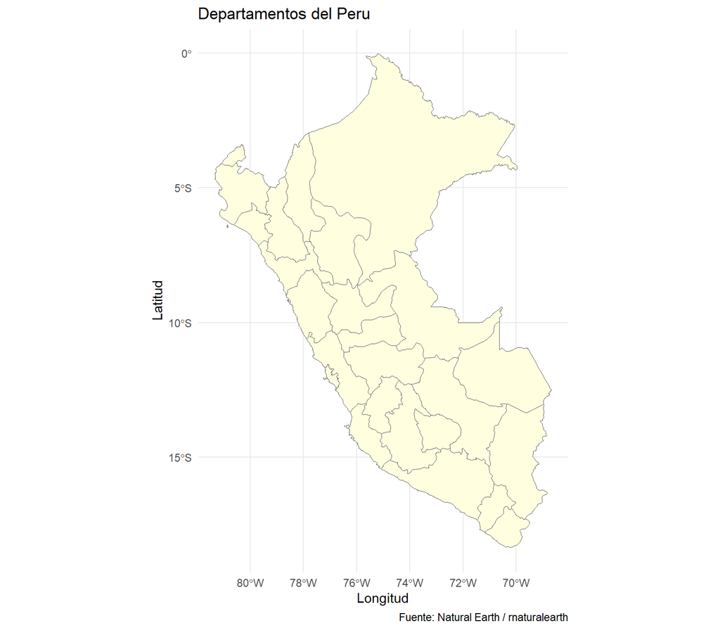

```r
ggplot(data = peru_d) +
  geom_sf(fill = "lightyellow", color = "gray40", size = 0.3) +
  labs(
    title   = "Departamentos del Peru",
    caption = "Fuente: Natural Earth / rnaturalearth",
    x = "Longitud", y = "Latitud"
  ) +
  theme_minimal()
```

## 4.3 Graficar un solo departamento

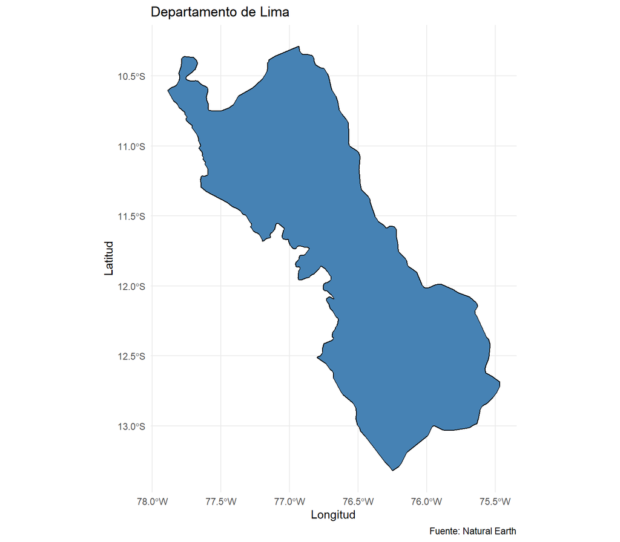

```r
ggplot(data = peru_d %>% filter(DEPARTAMEN == "LIMA")) +
  geom_sf(fill = "steelblue", color = "black", size = 0.4) +
  labs(
    title   = "Departamento de Lima",
    caption = "Fuente: Natural Earth",
    x = "Longitud", y = "Latitud"
  ) +
  theme_minimal()
```

## 4.4 Agregar etiquetas con centroides

Para mostrar el nombre de cada departamento en el mapa, calculamos el **centroide** (punto central) de cada poligono:

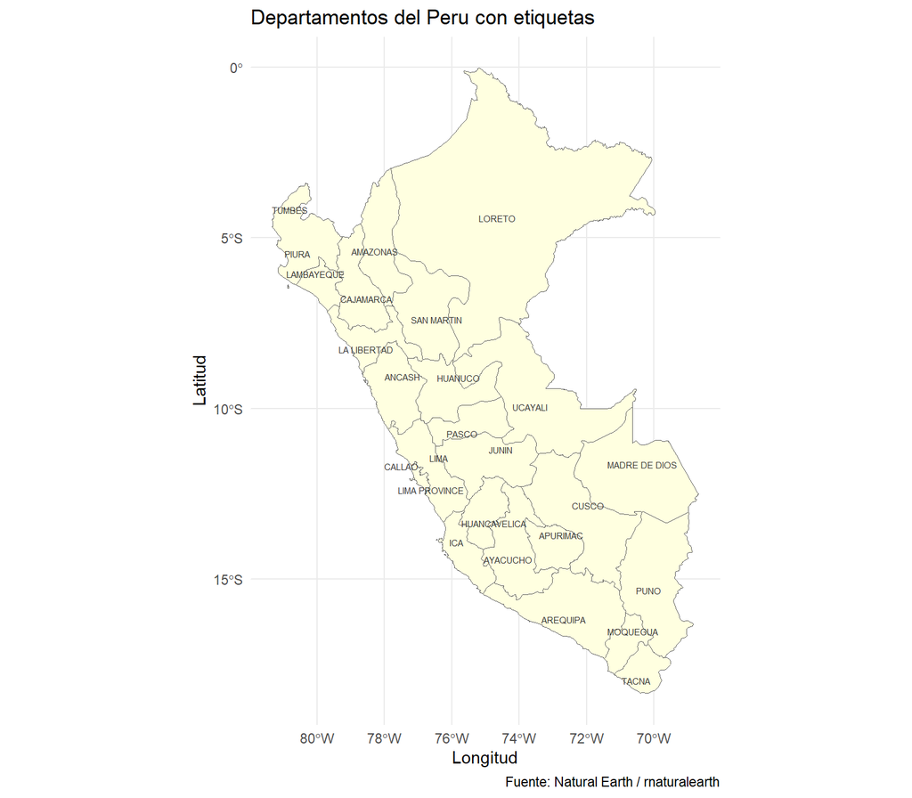

```r
# Calculo de centroides
peru_d <- peru_d %>%
  mutate(
    centroid = map(geometry, st_centroid),
    coords   = map(centroid, st_coordinates),
    coords_x = map_dbl(coords, 1),
    coords_y = map_dbl(coords, 2)
  )

# Mapa con etiquetas
ggplot(data = peru_d) +
  geom_sf(fill = "lightyellow", color = "gray40", size = 0.3) +
  geom_text_repel(
    mapping = aes(coords_x, coords_y, label = DEPARTAMEN),
    size    = 2.0,
    color   = "gray20"
  ) +
  labs(
    title   = "Departamentos del Peru con etiquetas",
    caption = "Fuente: Natural Earth / rnaturalearth",
    x = "Longitud", y = "Latitud"
  ) +
  theme_minimal()
```

# 5 Incorporacion de Datos Electorales (ONPE 2026)

## 5.1 Descripcion de los datos

Los datos provienen del conteo oficial de la ONPE para la primera vuelta de las Elecciones Generales 2026 (>94% de actas procesadas al 20 de abril de 2026).

> **Regla de oro del join:** El nombre de los departamentos debe coincidir *exactamente* con la columna `DEPARTAMEN` del shapefile (MAYUSCULAS, sin tildes). Por eso usamos `stri_trans_general()` al procesar el shapefile.

## 5.2 Carga y visualizacion de los datos electorales

```r
elecciones_2026 <- data.frame(
  DEPARTAMEN = c("AMAZONAS","ANCASH","APURIMAC","AREQUIPA","AYACUCHO",
                 "CAJAMARCA","CALLAO","CUSCO","HUANCAVELICA","HUANUCO",
                 "ICA","JUNIN","LA LIBERTAD","LAMBAYEQUE","LIMA",
                 "LORETO","MADRE DE DIOS","MOQUEGUA","PASCO","PIURA",
                 "PUNO","SAN MARTIN","TACNA","TUMBES","UCAYALI"),
  keiko_pct    = c(17.44, 18.05,  6.90,  7.80,  8.10,
                   13.82, 20.67,  5.90,  7.06, 15.44,
                   20.33, 17.00, 20.26, 26.41, 17.87,
                   28.13, 13.58,  6.80, 18.67, 27.97,
                    4.50, 23.25,  6.50, 33.96, 29.53),
  rsanchez_pct = c(36.08, 14.94, 40.88, 10.04, 31.29,
                   41.70,  9.20, 22.74, 43.38, 29.42,
                    8.50, 12.22,  9.40, 10.64,  7.30,
                    9.91, 23.23, 12.82, 18.74, 11.35,
                   24.82, 23.78, 11.89,  6.87, 12.91),
  ganador = c(
    "Roberto Sanchez","Keiko Fujimori","Roberto Sanchez",
    "Jorge Nieto","Roberto Sanchez","Roberto Sanchez",
    "Keiko Fujimori","Roberto Sanchez","Roberto Sanchez",
    "Roberto Sanchez","Keiko Fujimori","Keiko Fujimori",
    "Keiko Fujimori","Keiko Fujimori","Rafael Lopez Aliaga",
    "Keiko Fujimori","Roberto Sanchez","Roberto Sanchez",
    "Roberto Sanchez","Keiko Fujimori","Roberto Sanchez",
    "Roberto Sanchez","Ricardo Belmont","Keiko Fujimori",
    "Keiko Fujimori"),
  partido_ganador = c(
    "Juntos por el Peru","Fuerza Popular","Juntos por el Peru",
    "Partido del Buen Gobierno","Juntos por el Peru","Juntos por el Peru",
    "Fuerza Popular","Juntos por el Peru","Juntos por el Peru",
    "Juntos por el Peru","Fuerza Popular","Fuerza Popular",
    "Fuerza Popular","Fuerza Popular","Renovacion Popular",
    "Fuerza Popular","Juntos por el Peru","Juntos por el Peru",
    "Juntos por el Peru","Fuerza Popular","Juntos por el Peru",
    "Juntos por el Peru","Partido Civico Obras",
    "Fuerza Popular","Fuerza Popular"),
  stringsAsFactors = FALSE
)

knitr::kable(
  elecciones_2026,
  caption   = "Tabla 3. Resultados por departamento — Primera vuelta 2026 (ONPE, >94% actas)",
  col.names = c("Departamento","% Keiko Fujimori","% Roberto Sanchez",
                "Candidato Ganador","Partido Ganador"),
  digits    = 2,
  align     = c("l","r","r","l","l")
)
```

Tabla 3. Resultados por departamento — Primera vuelta 2026 (ONPE, >94% actas)

| Departamento | % Keiko Fujimori | % Roberto Sanchez | Candidato Ganador | Partido Ganador |
| --- | --- | --- | --- | --- |
| AMAZONAS | 17.44 | 36.08 | Roberto Sanchez | Juntos por el Peru |
| ANCASH | 18.05 | 14.94 | Keiko Fujimori | Fuerza Popular |
| APURIMAC | 6.90 | 40.88 | Roberto Sanchez | Juntos por el Peru |
| AREQUIPA | 7.80 | 10.04 | Jorge Nieto | Partido del Buen Gobierno |
| AYACUCHO | 8.10 | 31.29 | Roberto Sanchez | Juntos por el Peru |
| CAJAMARCA | 13.82 | 41.70 | Roberto Sanchez | Juntos por el Peru |
| CALLAO | 20.67 | 9.20 | Keiko Fujimori | Fuerza Popular |
| CUSCO | 5.90 | 22.74 | Roberto Sanchez | Juntos por el Peru |
| HUANCAVELICA | 7.06 | 43.38 | Roberto Sanchez | Juntos por el Peru |
| HUANUCO | 15.44 | 29.42 | Roberto Sanchez | Juntos por el Peru |
| ICA | 20.33 | 8.50 | Keiko Fujimori | Fuerza Popular |
| JUNIN | 17.00 | 12.22 | Keiko Fujimori | Fuerza Popular |
| LA LIBERTAD | 20.26 | 9.40 | Keiko Fujimori | Fuerza Popular |
| LAMBAYEQUE | 26.41 | 10.64 | Keiko Fujimori | Fuerza Popular |
| LIMA | 17.87 | 7.30 | Rafael Lopez Aliaga | Renovacion Popular |
| LORETO | 28.13 | 9.91 | Keiko Fujimori | Fuerza Popular |
| MADRE DE DIOS | 13.58 | 23.23 | Roberto Sanchez | Juntos por el Peru |
| MOQUEGUA | 6.80 | 12.82 | Roberto Sanchez | Juntos por el Peru |
| PASCO | 18.67 | 18.74 | Roberto Sanchez | Juntos por el Peru |
| PIURA | 27.97 | 11.35 | Keiko Fujimori | Fuerza Popular |
| PUNO | 4.50 | 24.82 | Roberto Sanchez | Juntos por el Peru |
| SAN MARTIN | 23.25 | 23.78 | Roberto Sanchez | Juntos por el Peru |
| TACNA | 6.50 | 11.89 | Ricardo Belmont | Partido Civico Obras |
| TUMBES | 33.96 | 6.87 | Keiko Fujimori | Fuerza Popular |
| UCAYALI | 29.53 | 12.91 | Keiko Fujimori | Fuerza Popular |

## 5.3 Union (join) con el shapefile

Realizamos un `left_join` usando `DEPARTAMEN` como variable llave:

```r
peru_datos <- peru_d %>%
  left_join(elecciones_2026, by = "DEPARTAMEN") %>%
  mutate(diferencia = rsanchez_pct - keiko_pct)

# Verificacion: departamentos sin datos electorales
cat("Departamentos sin datos:", sum(is.na(peru_datos$keiko_pct)), "\n")
```

```
## Departamentos sin datos: 1
```

```r
cat("Total de filas:", nrow(peru_datos), "\n")
```

```
## Total de filas: 26
```

# 6 Mapas Tematicos Electorales

## 6.1 Mapa 1: Porcentaje de votos de Keiko Fujimori

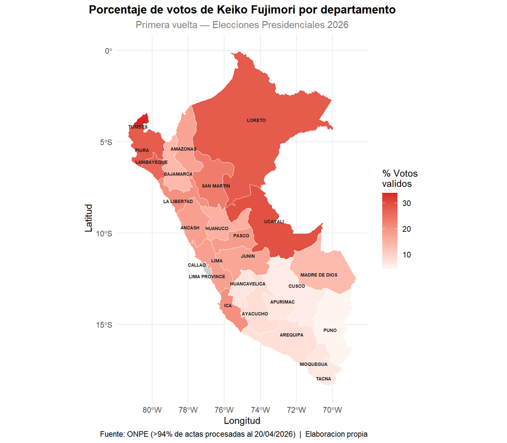

```r
ggplot(peru_datos) +
  geom_sf(aes(fill = keiko_pct), color = "white", size = 0.3) +
  geom_text_repel(
    mapping     = aes(coords_x, coords_y, label = DEPARTAMEN),
    size        = 1.8,
    color       = "gray10",
    fontface    = "bold",
    box.padding = 0.2,
    na.rm       = TRUE
  ) +
  scale_fill_gradient(
    low      = "#fff5f0",
    high     = "#d62728",
    name     = "% Votos\nvalidos",
    na.value = "gray80"
  ) +
  labs(
    title    = "Porcentaje de votos de Keiko Fujimori por departamento",
    subtitle = "Primera vuelta — Elecciones Presidenciales 2026",
    caption  = "Fuente: ONPE (>94% de actas procesadas al 20/04/2026)  |  Elaboracion propia",
    x = "Longitud", y = "Latitud"
  ) +
  theme_minimal(base_size = 11) +
  theme(
    plot.title    = element_text(face = "bold", hjust = 0.5),
    plot.subtitle = element_text(hjust = 0.5, color = "gray50"),
    legend.position = "right"
  )
```

> **Interpretacion:** Los departamentos mas oscuros (Tumbes: 34.0%, Ucayali: 29.5%, Piura: 28.0%, Loreto: 28.1%) reflejan el mayor respaldo a Fujimori en la costa norte y la selva. Los mas claros (Puno: 4.5%, Cusco: 5.9%, Apurimac: 6.9%) corresponden al sur andino donde su votacion fue minima.

## 6.2 Mapa 2: Candidato ganador por departamento

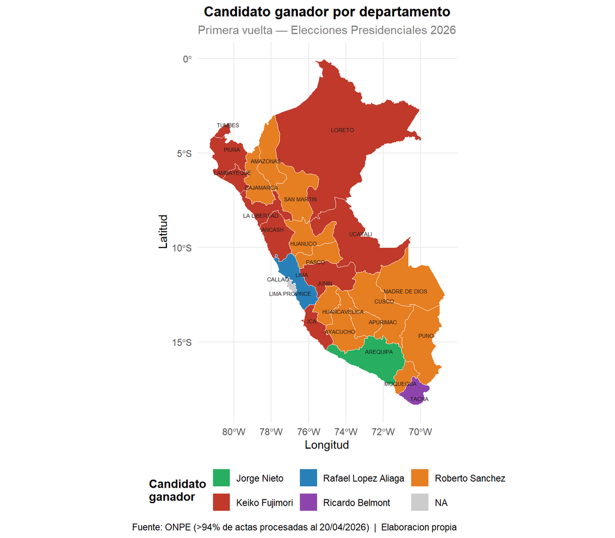

```r
colores_candidatos <- c(
  "Keiko Fujimori"     = "#c0392b",
  "Roberto Sanchez"    = "#e67e22",
  "Rafael Lopez Aliaga"= "#2980b9",
  "Jorge Nieto"        = "#27ae60",
  "Ricardo Belmont"    = "#8e44ad"
)

ggplot(peru_datos) +
  geom_sf(aes(fill = ganador), color = "white", size = 0.3) +
  geom_text_repel(
    mapping     = aes(coords_x, coords_y, label = DEPARTAMEN),
    size        = 1.8,
    color       = "gray10",
    box.padding = 0.2,
    na.rm       = TRUE
  ) +
  scale_fill_manual(
    values   = colores_candidatos,
    name     = "Candidato\nganador",
    na.value = "gray80"
  ) +
  labs(
    title    = "Candidato ganador por departamento",
    subtitle = "Primera vuelta — Elecciones Presidenciales 2026",
    caption  = "Fuente: ONPE (>94% de actas procesadas al 20/04/2026)  |  Elaboracion propia",
    x = "Longitud", y = "Latitud"
  ) +
  theme_minimal(base_size = 11) +
  theme(
    plot.title      = element_text(face = "bold", hjust = 0.5),
    plot.subtitle   = element_text(hjust = 0.5, color = "gray50"),
    legend.position = "bottom",
    legend.title    = element_text(face = "bold")
  ) +
  guides(fill = guide_legend(nrow = 2))
```

> **Interpretacion:** Keiko Fujimori (rojo) gano en 10 departamentos de la costa norte y selva. Roberto Sanchez (naranja) domino en 12 departamentos de la sierra central y sur. Rafael Lopez Aliaga (azul) vencio unicamente en Lima, Jorge Nieto (verde) en Arequipa, y Ricardo Belmont (morado) en Tacna.

## 6.3 Mapa 3: Diferencia de votos entre Sanchez y Fujimori

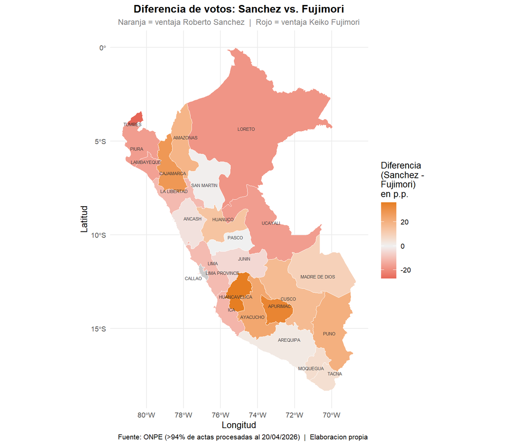

```r
ggplot(peru_datos) +
  geom_sf(aes(fill = diferencia), color = "white", size = 0.3) +
  geom_text_repel(
    mapping     = aes(coords_x, coords_y, label = DEPARTAMEN),
    size        = 1.7,
    color       = "gray20",
    box.padding = 0.15,
    na.rm       = TRUE
  ) +
  scale_fill_gradient2(
    low      = "#d62728",
    mid      = "#f0f0f0",
    high     = "#e67e22",
    midpoint = 0,
    name     = "Diferencia\n(Sanchez -\nFujimori)\nen p.p.",
    na.value = "gray80"
  ) +
  labs(
    title    = "Diferencia de votos: Sanchez vs. Fujimori",
    subtitle = "Naranja = ventaja Roberto Sanchez  |  Rojo = ventaja Keiko Fujimori",
    caption  = "Fuente: ONPE (>94% de actas procesadas al 20/04/2026)  |  Elaboracion propia",
    x = "Longitud", y = "Latitud"
  ) +
  theme_minimal(base_size = 10) +
  theme(
    plot.title    = element_text(face = "bold", hjust = 0.5, size = 12),
    plot.subtitle = element_text(hjust = 0.5, color = "gray50", size = 9),
    legend.position = "right"
  )
```

# 7 Analisis de Resultados

## 7.1 Tabla resumen de ganadores

```r
resumen <- elecciones_2026 %>%
  group_by(ganador, partido_ganador) %>%
  summarise(
    n_departamentos = n(),
    keiko_prom      = round(mean(keiko_pct), 1),
    sanchez_prom    = round(mean(rsanchez_pct), 1),
    .groups         = "drop"
  ) %>%
  arrange(desc(n_departamentos))

knitr::kable(
  resumen,
  caption   = "Tabla 4. Resumen de departamentos ganados por candidato — Primera vuelta 2026",
  col.names = c("Candidato","Partido","Depts. ganados",
                "% Keiko promedio","% Sanchez promedio"),
  align     = c("l","l","c","r","r")
)
```

Tabla 4. Resumen de departamentos ganados por candidato — Primera vuelta 2026

| Candidato | Partido | Depts. ganados | % Keiko promedio | % Sanchez promedio |
| --- | --- | --- | --- | --- |
| Roberto Sanchez | Juntos por el Peru | 12 | 11.8 | 29.1 |
| Keiko Fujimori | Fuerza Popular | 10 | 24.2 | 10.6 |
| Jorge Nieto | Partido del Buen Gobierno | 1 | 7.8 | 10.0 |
| Rafael Lopez Aliaga | Renovacion Popular | 1 | 17.9 | 7.3 |
| Ricardo Belmont | Partido Civico Obras | 1 | 6.5 | 11.9 |

## 7.2 Patrones regionales observados

El analisis geoespacial revela patrones territoriales claramente marcados:

**Keiko Fujimori (Fuerza Popular):** Sus mejores resultados se concentran en la costa norte (Tumbes: 34.0%, Piura: 28.0%, Lambayeque: 26.4%) y la selva (Ucayali: 29.5%, Loreto: 28.1%). Gano en **10 departamentos**.

**Roberto Sanchez (Juntos por el Peru):** Domino ampliamente en la sierra central y sur: Huancavelica (43.4%), Cajamarca (41.7%), Apurimac (40.9%), Ayacucho (31.3%). Gano en **12 departamentos**, la mayoria rurales.

**Rafael Lopez Aliaga (Renovacion Popular):** Su voto se concentro en Lima (19.9%), donde gano, reflejando su perfil de candidato urbano de centro-derecha.

**Jorge Nieto (Partido del Buen Gobierno):** Gano en Arequipa (18.7%), region con tradicion de voto diferenciado respecto al resto del sur.

**Ricardo Belmont (Partido Civico Obras):** Vencio en Tacna (14.6%), en un escenario de alta fragmentacion del voto.

# 8 Conclusiones

En este tutorial aprendimos a:

1. **Descargar shapefiles directamente en R** con `rnaturalearth::ne_states()`, sin necesidad de buscar archivos externos.
2. **Estandarizar nombres geograficos** con `stringi::stri_trans_general()` para hacer joins sin errores de tildes o mayusculas.
3. **Calcular centroides** con `purrr::map()` y `sf::st_centroid()` para posicionar etiquetas sobre los poligonos.
4. **Unir datos tabulares** (resultados electorales) con datos geoespaciales mediante `left_join()`.
5. **Construir 3 tipos de mapas**: gradiente continuo, categorico por candidato, y escala divergente de diferencias.

El analisis confirma la fuerte fragmentacion del voto en la primera vuelta 2026 y los patrones regionales historicos del electorado peruano: la sierra apoya a candidatos de izquierda/protesta, mientras que la costa norte y la selva muestran mayor afinidad con Fuerza Popular.

# 9 Referencias

- **ONPE** (2026). *Resultados Electorales — Elecciones Generales 2026*. Recuperado de https://resultadoelectoral.onpe.gob.pe
- Condor, R. M. (2020). *Elaboracion de Mapas con R*. Recuperado de https://rpubs.com/rcondor/619184
- South, A. (2017). *rnaturalearth: World Map Data from Natural Earth*. R package version 0.1.0.
- Pebesma, E. (2018). Simple Features for R. *The R Journal*, 10(1), 439-446.
- Wickham, H. et al. (2019). Welcome to the tidyverse. *JOSS*, 4(43), 1686.